# End-to-end workflow for LC-MS/MS analysis using *MsExperiment* and *Spectra*

Philippine Louail

2023-09-07

# Abstract

# Keyword

LC-MS/MS, pre-processing, normalization, feature identification…

# Introduction

- Relevancy of the technic
- Challenges (explaining the need for seamless integragration and overall pipeline)
- Thus we propose a highly-detailed and adaptable pipeline for LC-MS/MS data analysis. Comprised of pre-processing steps based on the *xcms* package, which is highly adaptable to dataset-specific requirement…

# Data description

# Workflow description

This pipeline here describes all steps required to preprocess and assign features identity to LC-MS/MS data. It is performed thanks to the *MsExperiment* and *PSpectra* packages that integrate multiple Bioconductor packages for LC-MS/MS analysis. The pre-processing steps are performed using the *xcms* packages and consist of Chromatogrphic peak detection, retention time alignment and Correspondence. The pre-processing of the data is then followed by normalization, identification of features and lastly annotation of these features. Laslty, *RColorBrewer*, *pander*, and *pheatmap* were used for data visualization.

Our workflow is therefore based on the following dependencies:

```r
library(MsExperiment)
library(xcms)
library(Spectra)
library(RColorBrewer)
library(pander)
library(readxl)
library(MetaboCoreUtils)
library(pheatmap)
```

# Data import

The *mzML* files with the raw MS data are located within the *data/mzML* folder of this repository. [ideally, they should be added and then downloaded from MassIVE].

```r
#' read the sample descriptions from an xlsx sheet
pd <- read_xlsx("data/phenodata.xlsx") |>
    as.data.frame()

#' Import the data
#' Massive data bank extraction but for now not.
MZML_PATH <- "C:/Users/plouail/OneDrive - Scientific Network South Tyrol/end-to-end_worflow/data/mzML"

#' register(MulticoreParam(6)) ask johannes about that
data <- readMsExperiment(paste0(MZML_PATH, "/", pd$mzML_file) ,sampleData = pd)
```

```r
#' Set up parallel processing using 2 cores
if (.Platform$OS.type == "unix") {
    register(bpstart(MulticoreParam(2)))
} else {
    register(bpstart(SnowParam(2)))
}
```

# Data organisation

The experimental data is now a `MsExperiment` object:

```r
data
```

```
## Object of class MsExperiment
##  Spectra: MS1 (17210)
##  Experiment data: 10 sample(s)
##  Sample data links:
##   - spectra: 10 sample(s) to 17210 element(s).
```

This `MsExperiment` object manages the linkage between samples and spectra. Its length is defined by the number of samples within the object. The phenodata is a crucial aspect of LC-MS/MS analysis. It can be accessed using `sampleData()`. The Table 1 below shows us more details about our dataset’s samples.

Metadata in our `MsExperiment` object is accessed using the `sampleData()` function. we used this and the *pander* package to build this table representing the metadata of our study (table 1)

```
##
##
## |         mzML_file         | injection_index | phenotype | sample_name |
## |:-------------------------:|:---------------:|:---------:|:-----------:|
## |   20180622_QC4_POS.mzML   |       45        |    QC     |   POOL_1    |
## | 20180622_ARVD 15_POS.mzML |       50        |    CVD    |      A      |
## |  20180622_CTR21_POS.mzML  |       51        |    CTR    |      B      |
## |   20180622_QC7_POS.mzML   |       78        |    QC     |   POOL_2    |
## |  20180622_CTR25_POS.mzML  |       82        |    CTR    |      C      |
## | 20180622_ARVD 8_POS.mzML  |       85        |    CVD    |      D      |
## |   20180622_QC8_POS.mzML   |       89        |    QC     |   POOL_3    |
## |  20180622_CTR22_POS.mzML  |       93        |    CTR    |      E      |
## | 20180622_ARVD 5_POS.mzML  |       94        |    CVD    |      F      |
## |   20180622_QC9_POS.mzML   |       99        |    QC     |   POOL_4    |
##
## Table: Samples from the data set.
```

The MS data of this experiment is stored as a `Spectra` object within the `MsExperiment` object and can be accessed using `Spectra()` function. Each element in this object is a spectrum - they are organised linearly and are all combined in the same `spectra` object one after the other (through retention time and samples).

```r
# Access Spectra Object
spectra(data)
```

```
## MSn data (Spectra) with 17210 spectra in a MsBackendMzR backend:
##         msLevel     rtime scanIndex
##       <integer> <numeric> <integer>
## 1             1     0.274         1
## 2             1     0.553         2
## 3             1     0.832         3
## 4             1     1.111         4
## 5             1     1.390         5
## ...         ...       ...       ...
## 17206         1   479.052      1717
## 17207         1   479.331      1718
## 17208         1   479.610      1719
## 17209         1   479.889      1720
## 17210         1   480.168      1721
##  ... 33 more variables/columns.
##
## file(s):
## 20180622_QC4_POS.mzML
## 20180622_ARVD 15_POS.mzML
## 20180622_CTR21_POS.mzML
##  ... 7 more files
```

```r
# Check number of samples
length(data)
```

```
## [1] 10
```

We therefore have an data set of 10 samples for a total of 17210 spectra. Below we also determine the retention time range for the entire data set.

```r
#' Retention time range for entire dataset
spectra(data) |>
rtime() |>
range()
```

```
## [1]   0.273 480.169
```

Data coming from LC-MS experiments are usually analyzed along the retention time axis. MS data is organized by spectrum and hence orthogonal to the retention time axis. The `chromatogram()` function therefore allows to extract intensities along retention time. The access to chromatographic information is not as efficient and seamless as for spectra information but development of a `chromatogram` object as thorough and easy of use as the `Spectra` object is underway.

# Data visualization and general quality assessment

Visualization is crucial for inspection and quality assessment of MS data. To generate general overview of our LC-MS/MS we can:

- Combine all spectra measured into a single spectrum = Base peak spectrum (BPS)
- Aggregate peak intensity for each spectrum = Base peak chromatogram (BPC), which is orthogonal to the BPS

## Visualisation of spectra data

BPS collapses data in the retention time dimension. such visualization provides information on the most abundant mass-to-charge values (m/z) ub the data set regardless of the rtime in which they were measured. Compared to the BPC, BPS visualization is not as straightforward. Indeed, mass peaks, even if representing signal from the same ion, will never be identical between consecutive spectra, but will slightly differ based on the measurement error/resolution of the instrument.

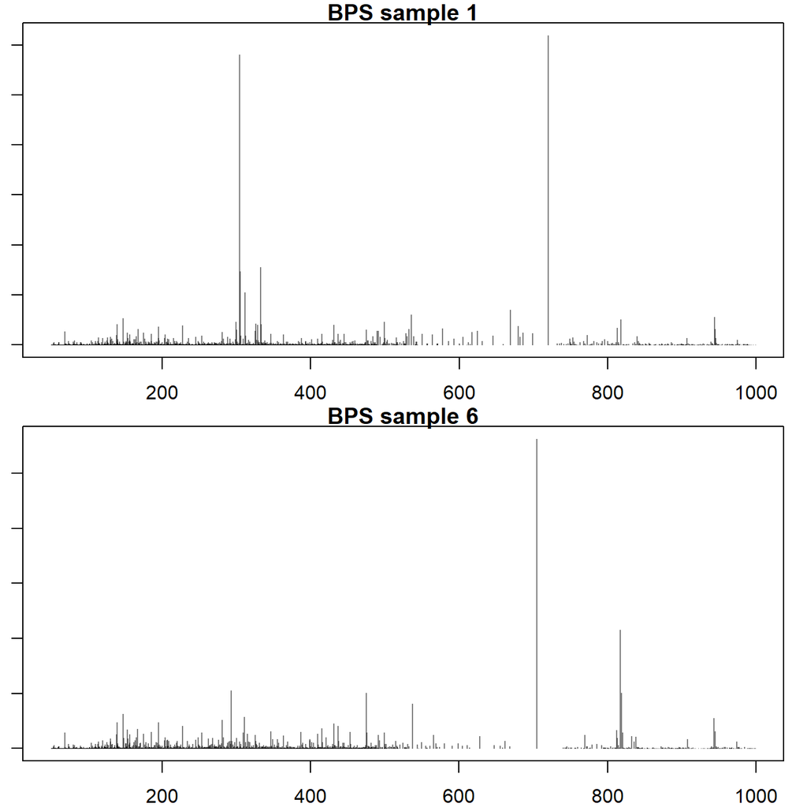

```r
bps <- spectra(data) |>
  combineSpectra(f = fromFile(data), intensityFun = max, ppm = 5)

par(mfrow = c(2,1), mar =c(2,1,1,1))
plotSpectra(bps[1], main = "BPS sample 1")
plotSpectra(bps[6], main = "BPS sample 6")
```

These BPS thus show the most common ions present in each of the samples. There seem to be some overlap in ion content between the files (around 300 m/z and 700 m/z), but also some quite distinct signals.

It is also highly suggested to explore the data in more details. This can easily be done by assessing our data extracting spectrum/region of interest.

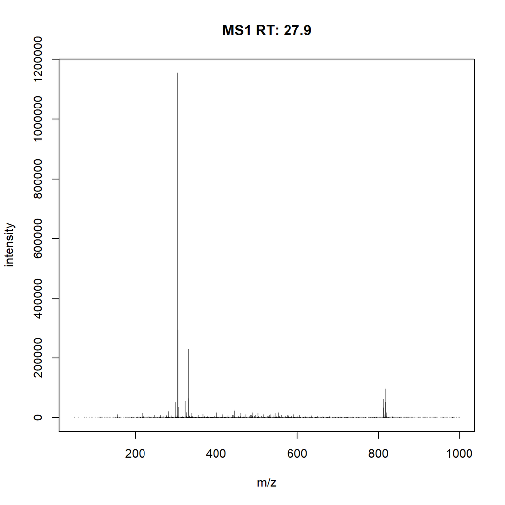

```r
#' Accessing a single spectrum
exspec <- spectra(data[1])[100]
plotSpectra(exspec)
```

We can then explore details about this specific spectrum by using a wide range of functions:

```r
#' checking its intensity
intensity(exspec)
```

```
## NumericList of length 1
## [[1]] 122.692307692295 76.6573426573426 ... 87.067599067599 141.467948717936
```

```r
#' checking its rtime
rtime(exspec)
```

```
## [1] 27.896
```

```r
#' Checking its m/z
mz(exspec)
```

```
## NumericList of length 1
## [[1]] 50.0165069383625 50.9399549212966 ... 999.419246229641 999.690820427148
```

We can focus on a specific subset of the data at a specific rtime range and then look at all the spectrum there

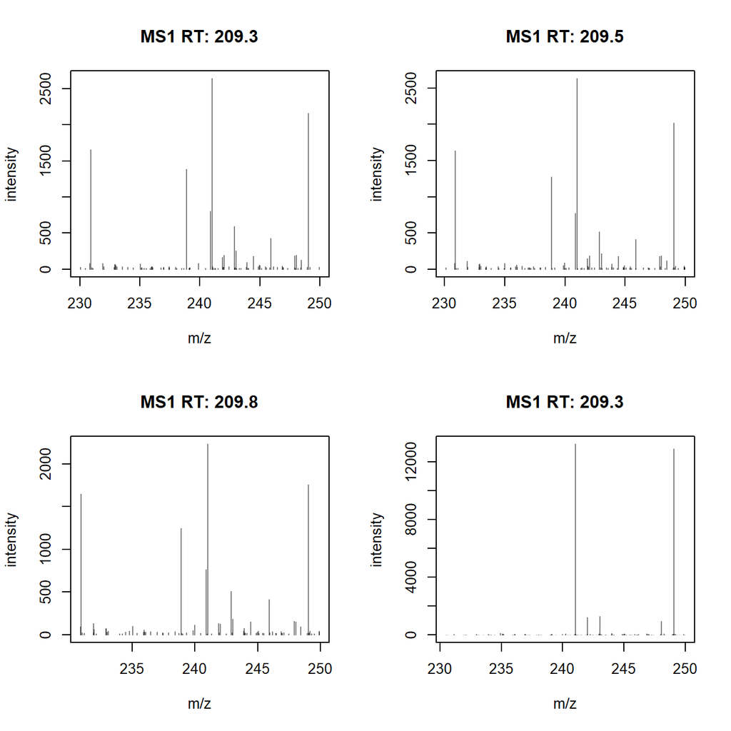

```r
exspec <- data |>
  filterMz(c(230,250)) |>
  spectra() |>
  filterRt(c(209,210))

plotSpectra(exspec[1:4])
```

There were 30 spectra measured in this one second within the entire dataset (we only show 4 here) . After plotting them, we can spot several mass peaks, a common peak can be seen at 241 m/z which could represent the ion of Cystine We can look into this a bit later.

## Visualization of chromatographic data

For LC-MS data visualizing, a base peak chromatogram (BPC) or total ion chromatogram (TIC) would for example allow to evaluate the performance of the liquid chromatography of the various samples in an experiment. To create such a plot we below extract the BPC from our data. The BPC extracts the maximum peak signal from each spectrum in a data file and plots this information (on the y-axis) against the retention time for that spectrum. The BPC can be extracted using the `chromatogram` function. With parameter `aggregationFun = "max"` we define to report the maximum signal per spectrum. On the other hand setting `aggregationFun = "sum"` sum up all intensities of a spectrum and hence create a TIC.

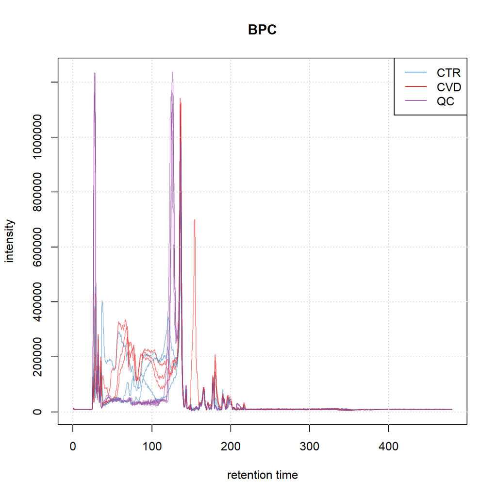

```r
#' First extract and plot bpc for full data
bpc <- chromatogram(data, aggregationFun = "max")
```

We can see the right part of the chromatogram seem empty, so we can remove it…

```r
#' Filter the data based on retention time
data <- filterRt(data, c(10, 240))
bpc <- chromatogram(data, aggregationFun = "max")
```

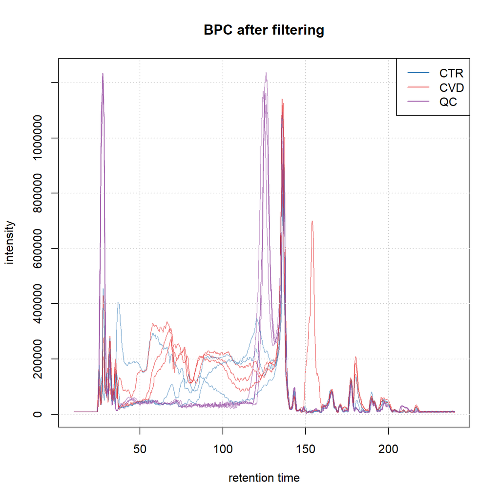

We first looked through the entire base peak chromatogram and then filtered it with specific retention time this allows to get smaller file size and an easier to read BPC.

This last plot hence shows th BPC for each samples and give us information on the retention time captured during our experiment, therefore at what retention time compounds eluted from the LC column. Essentially, a BPC collapses the 3-dimensional LC-MS data (m/z by retention time by intensity) into 2 dimensions (retention time by intensity)

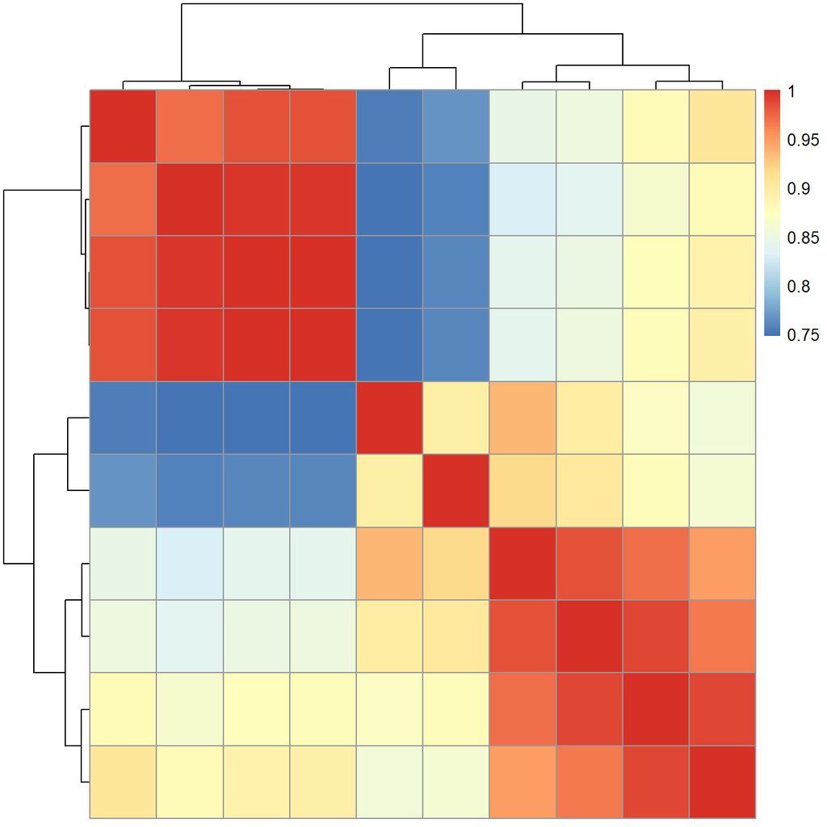

```r
#' Heatmap from total ion chromatogram
tic <- chromatogram(data, aggregationFun = "sum") |>
  bin(binSize = 2)

ticmap <- do.call(cbind, lapply(tic, intensity)) |>
  cor() |>
  pheatmap()
```

Throughout the entire process it is important to be able to refer to know part of the datat set, such as well known ions. In this workflow we selected ions that are commonly present in human blood serum. Below, we generate extracted ion chromatogram (EIC) for these “test ions”

```r
#'Calculating ion mass for:

#' Cystine
cystine_mz <- calculateMass("C6H12N2O4S2") |>
  mass2mz("[M+H]+")

cystine_mz <- cystine_mz[1, 1]

eic_cystine <- chromatogram(data, rt = c(195, 218),
                           mz = cystine_mz + c(-0.05, 0.05),
                           aggregationFun = "max")

#' 1- Methylhistidine
Met_mz <- calculateMass("C7H11N3O2") |>
  mass2mz("[M+H]+")

Met_mz <- Met_mz[1, 1]

eic_Met <- chromatogram(data, rt = c(170, 200),
                           mz = Met_mz + c(-0.05, 0.05), aggregationFun = "max")
```

Now we can `plot()` these EICs:

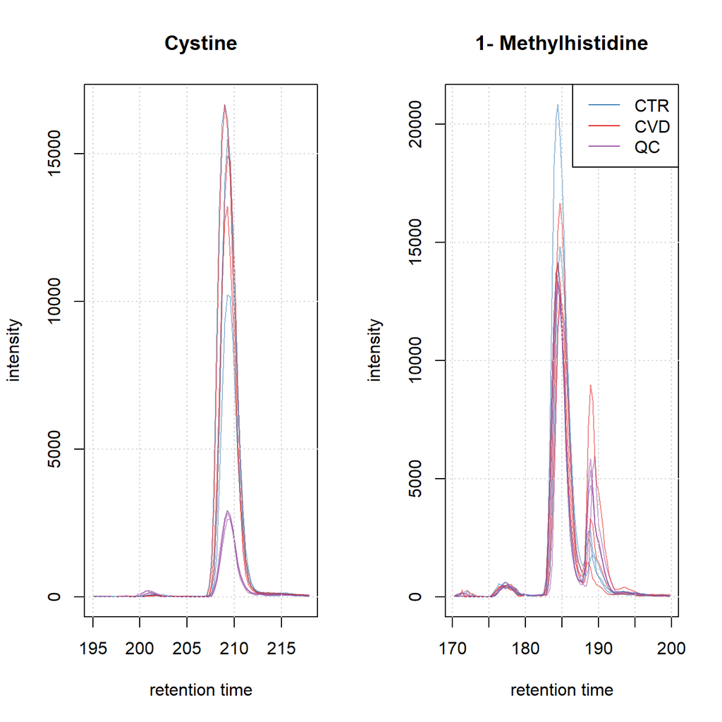

# Data pre-processing

Pre-processing is the first step in the analysis of untargeted LC-MS or gas chromatography (GC)-MS data. The aim of the pre-processing is the quantification of signals from ions measured in a sample, adjusting for any potential retention time drifts between samples and the matching of the quantified signal across samples within an experiment. ..

## Chromatographic peak detection

The first pre-processing step is to detect the presence of peaks along retention time. For this purpose we use the findChromPeaks function within xcms, the preferred algorithm is the CentwaveParam - better for non-Gaussian shape which is what we usually get with HILIC separation (other algorithm also exist)

```r
#' Use default Centwave parameter
param <- CentWaveParam()

#' Evaluate for Cystine
cystine_test <- findChromPeaks(eic_cystine, param = param)
chromPeaks(cystine_test)
```

```
##      rt rtmin rtmax into intb maxo sn row column
```

```r
#' Evaluate for 1- Methylhistidine
Met_test <- findChromPeaks(eic_Met, param = param)
chromPeaks(Met_test)
```

```
##      rt rtmin rtmax into intb maxo sn row column
```

refer to previous figures to determine peakwidth

```r
#' Restrict the data to signal from Cystine
cst <- data[1L] |>
  spectra() |>
  filterRt(rt = c(195, 218)) |>
  filterMzRange(mz = cystine_mz + c(-0.01, 0.01))

lengths(cst)
```

```
##  [1] 0 0 0 0 0 0 0 0 0 0 0 0 0 0 0 0 0 0 0 0 1 0 0 0 0 0 0 0 1 0 1 0 0 0 0 0 0 0
## [39] 0 0 0 0 0 0 0 0 1 1 1 1 1 1 1 1 1 1 1 1 1 1 1 1 1 1 1 1 1 1 1 1 1 1 1 1 1 1
## [77] 1 1 1 1 1 1 1
```

```r
#' Calculate the difference in m/z values between scans
mz_diff <- cst |>
    mz() |>
    unlist() |>
    diff() |>
    abs()

#' Express it in ppm
range(mz_diff * 1e6 / mean(unlist(mz(cst))))
```

```
## [1]  0.0320679 46.1344058
```

.. we take a ppm value close to the maximum of this range.

Now re-run with adapted settings.

```r
#' With more accurate parameters
param <- CentWaveParam(peakwidth = c(1, 8), ppm = 50, integrate = 2)

cystine_test <- findChromPeaks(eic_cystine, param = param)
head(chromPeaks(cystine_test))
```

```
##           rt   rtmin   rtmax      into      intb      maxo   sn row column
## [1,] 209.251 207.577 212.320  4983.763  4871.172  2638.615  154   1      1
## [2,] 209.251 206.461 217.622 25673.942 25431.709 13222.960 2279   1      2
## [3,] 209.252 207.299 214.553 20016.102 19890.829 10223.117 2302   1      3
## [4,] 209.251 205.624 213.436  5652.761  5418.964  2929.872   76   1      4
## [5,] 208.974 206.463 213.438 35799.372 35626.720 16681.469  968   1      5
## [6,] 209.250 207.297 213.714 29136.690 28794.939 14932.599  107   1      6
```

```r
Met_test <- findChromPeaks(eic_Met, param = param)
head(chromPeaks(Met_test))
```

```
##           rt   rtmin   rtmax       into       intb        maxo   sn row column
## [1,] 184.977 181.071 188.325 27268.9270 25705.9412 12355.00233   60   1      1
## [2,] 189.441 188.325 193.347  9565.5238  9560.2228  5950.25175 5949   1      1
## [3,] 193.905 193.347 194.742   316.7395   315.0655   232.19114  231   1      1
## [4,] 198.649 197.812 199.765   160.8445   158.6125    91.99883   91   1      1
## [5,] 184.699 182.467 187.768 26536.7192 25387.9040 12800.46387   58   1      2
## [6,] 188.884 187.768 192.232  5884.8335  5880.0905  3321.80186 3321   1      2
```

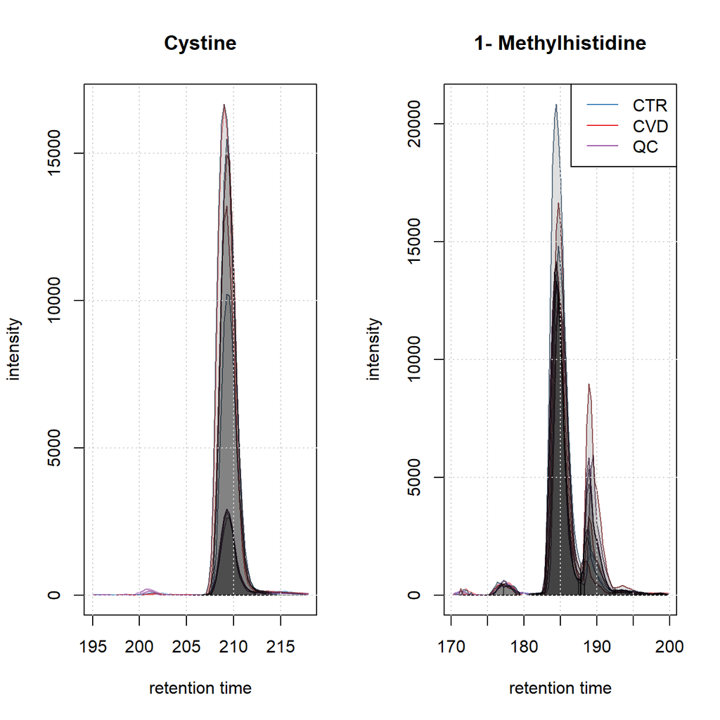

So we can go on to apply this algorithm to the entire data set we then extract the EIC for our two ions test.

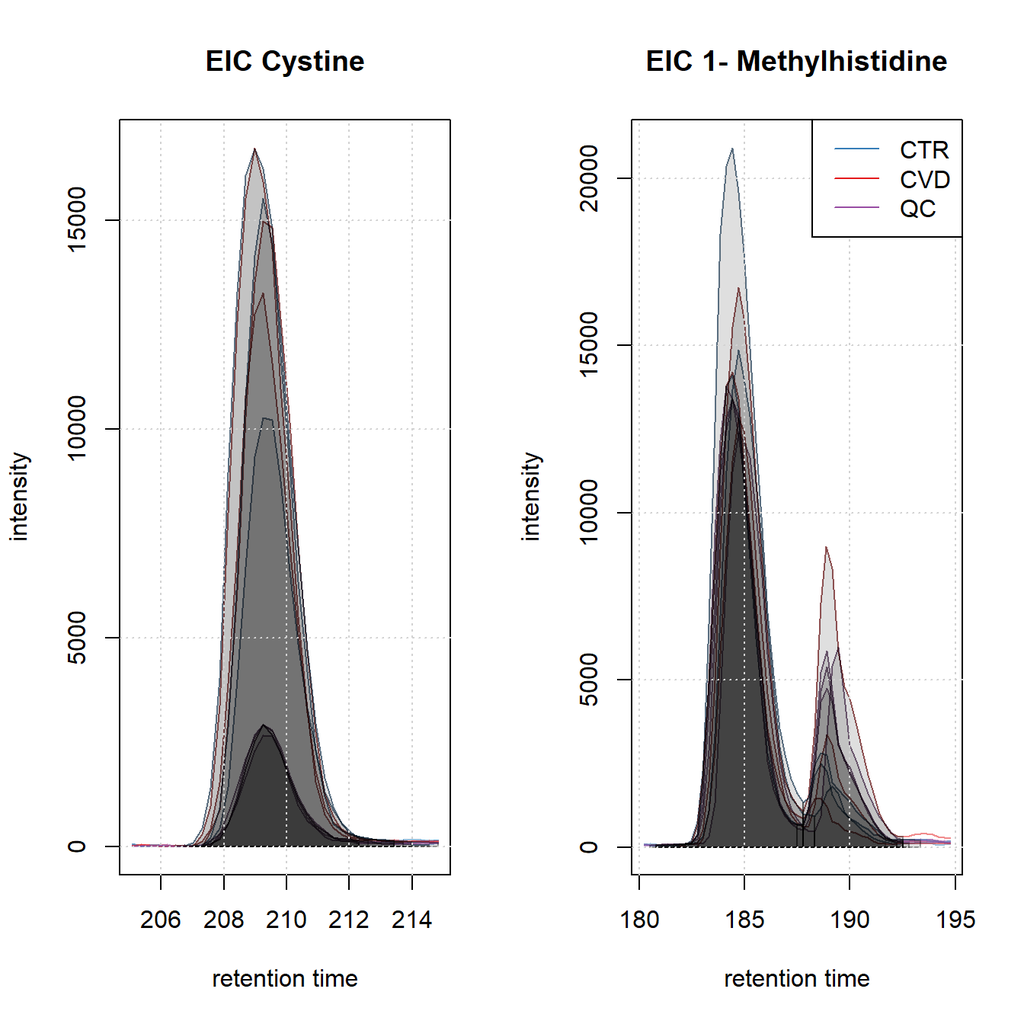

```r
data <- findChromPeaks(data, param = param, chunkSize = 5)

#' Test if we find cystine and 1- Methylhistidine again
eic_cystine <- chromatogram(data, mz = cystine_mz + c(-0.05, 0.05),
                           rt = c(205, 215))

eic_Met <- chromatogram(data, mz = Met_mz + c(-0.05, 0.05),
                           rt = c(180, 195))
```

The EICs confirm the Chromatographic peak detection was successful. These chrompeaks can also be seen in generic plots such as below:

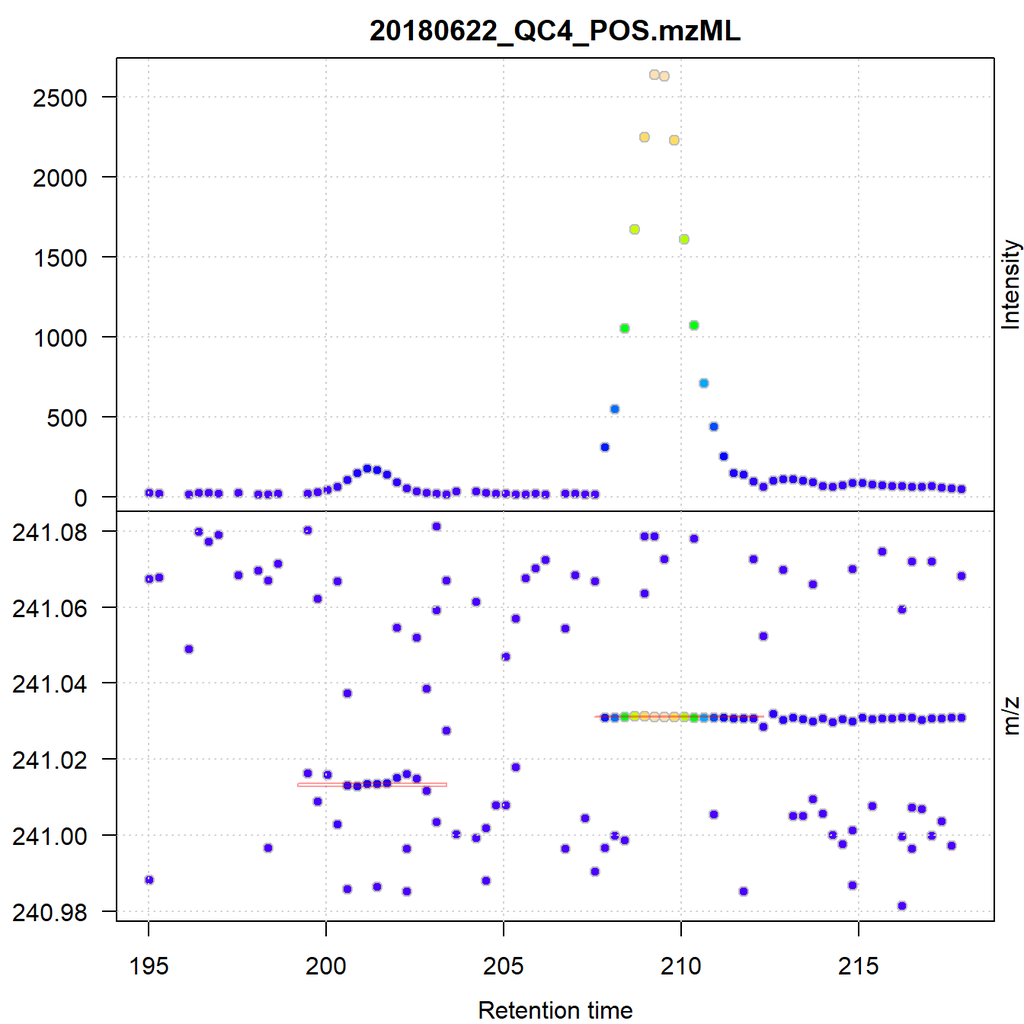

```r
data[1] |>
  filterRt(rt = c(195, 218)) |>
  filterMz(mz = cystine_mz + c(-0.05, 0.05)) |>
  plot() # discuss this, because ugly small peak
```

### Refine chromatographic peaks

The identification of chromatographic peaks can sometimes lead to peak detection artifacts, either overlapping or splits. The function `refineChromPeaks` is used in this case in combination with the `MergeNeighboringPeaksParam`. This function will merge peaks that were artificially split in the previous step.

A few examples of peak detection artifacts:

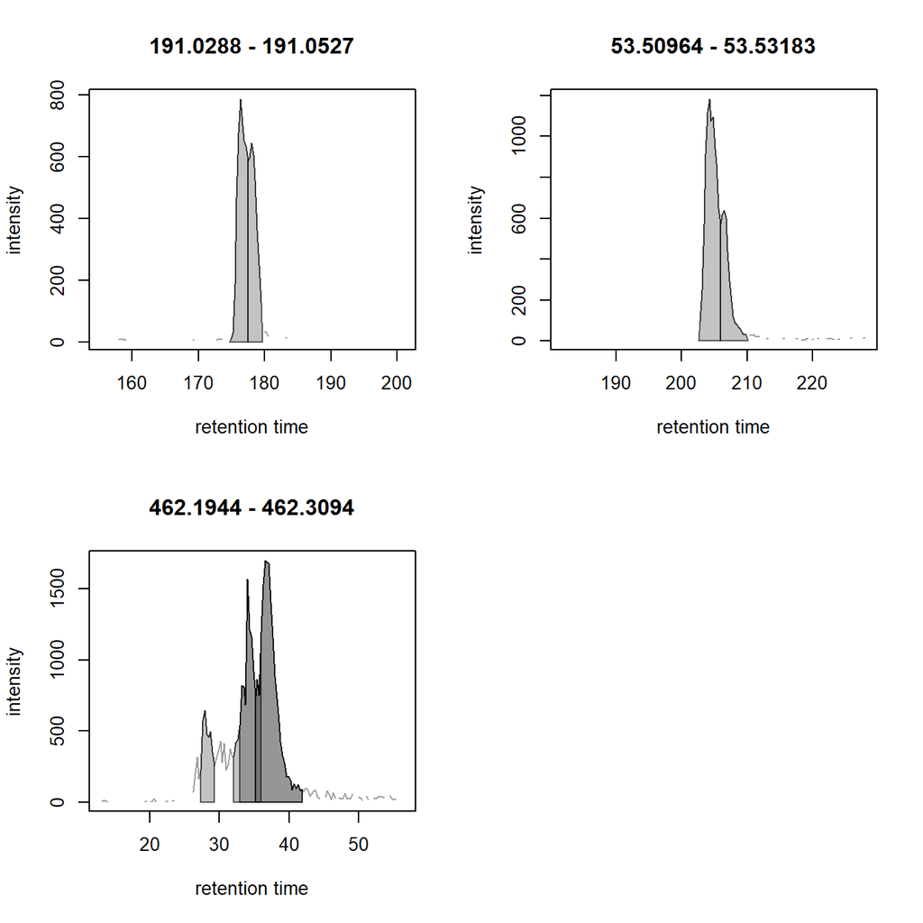

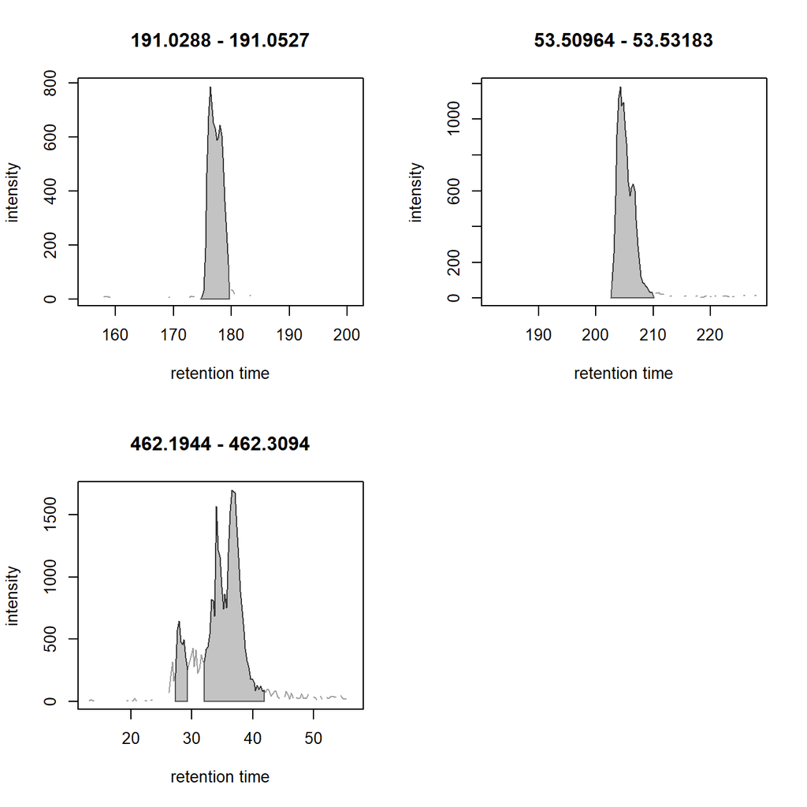

```r
#' set up the parameter
param <- MergeNeighboringPeaksParam(expandRt = 2.5, expandMz = 0.001,
                                   minProp = 3/4)

#' Perform the peak refinement on the EICs
eics <- refineChromPeaks(eics, param = param)
plot(eics)
```

- the parameters chosen
- the changes.

```r
#' Apply on whole dataset
data <- refineChromPeaks(data, param = param, chunkSize = 5)
chromPeakData(data)
```

```
## DataFrame with 96102 rows and 3 columns
##           ms_level is_filled    merged
##          <integer> <logical> <logical>
## CP000010         1     FALSE     FALSE
## CP000011         1     FALSE     FALSE
## CP000014         1     FALSE     FALSE
## CP000015         1     FALSE     FALSE
## CP000016         1     FALSE     FALSE
## ...            ...       ...       ...
## CP122681         1     FALSE      TRUE
## CP122682         1     FALSE      TRUE
## CP122683         1     FALSE      TRUE
## CP122684         1     FALSE      TRUE
## CP122685         1     FALSE      TRUE
```

## Retention time alignment

- use initial correspondence.

Let’s build and look at the bpc again:

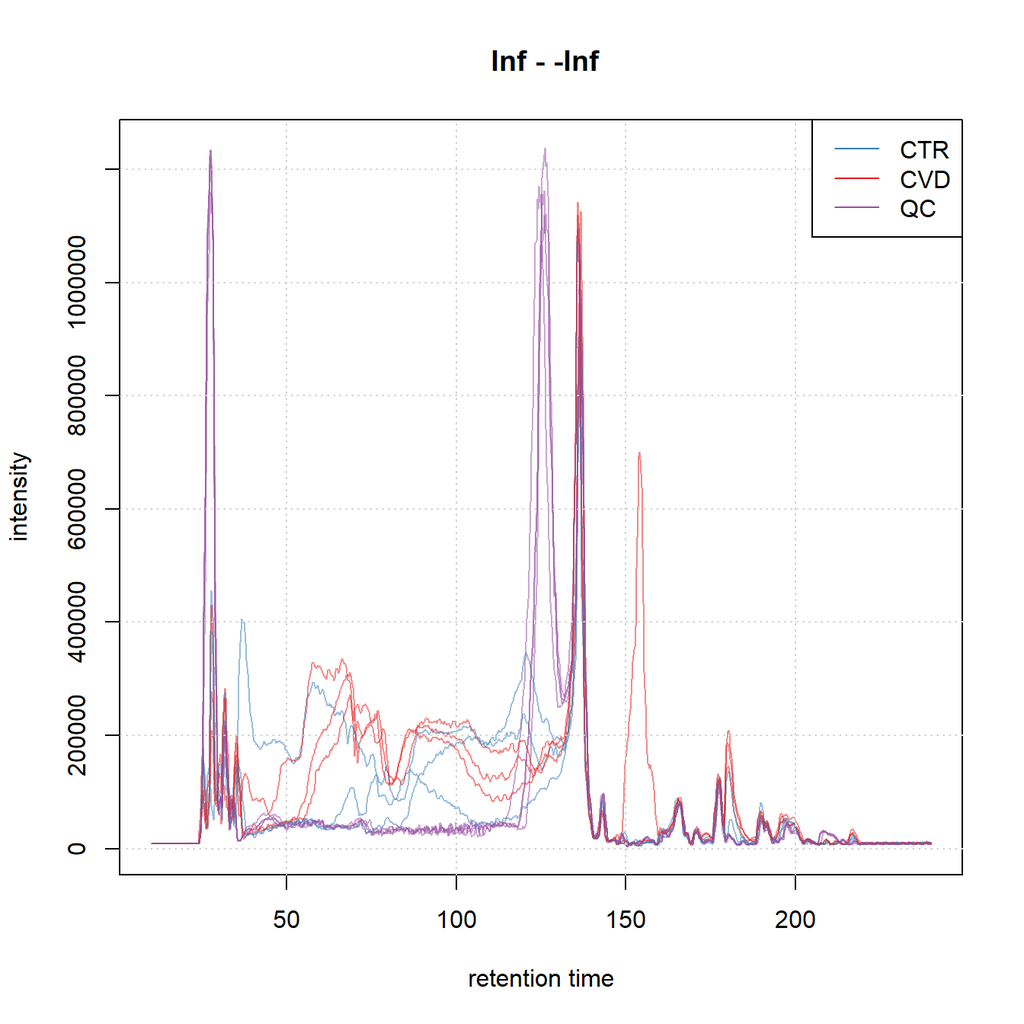

Here we can see that the QC samples that were measured with the same setup on the same day show a slight drifts of the signal are visible.

- Discuss protocol, find main peaks to base the lignment to,…

```r
# Grouping the peaks according to
param <- PeakDensityParam(sampleGroups = sampleData(data)$phenotype,
                        minFraction = 0.75,
                        binSize = 0.01,
                        bw = 2)
data <- groupChromPeaks(data, param = param)
```

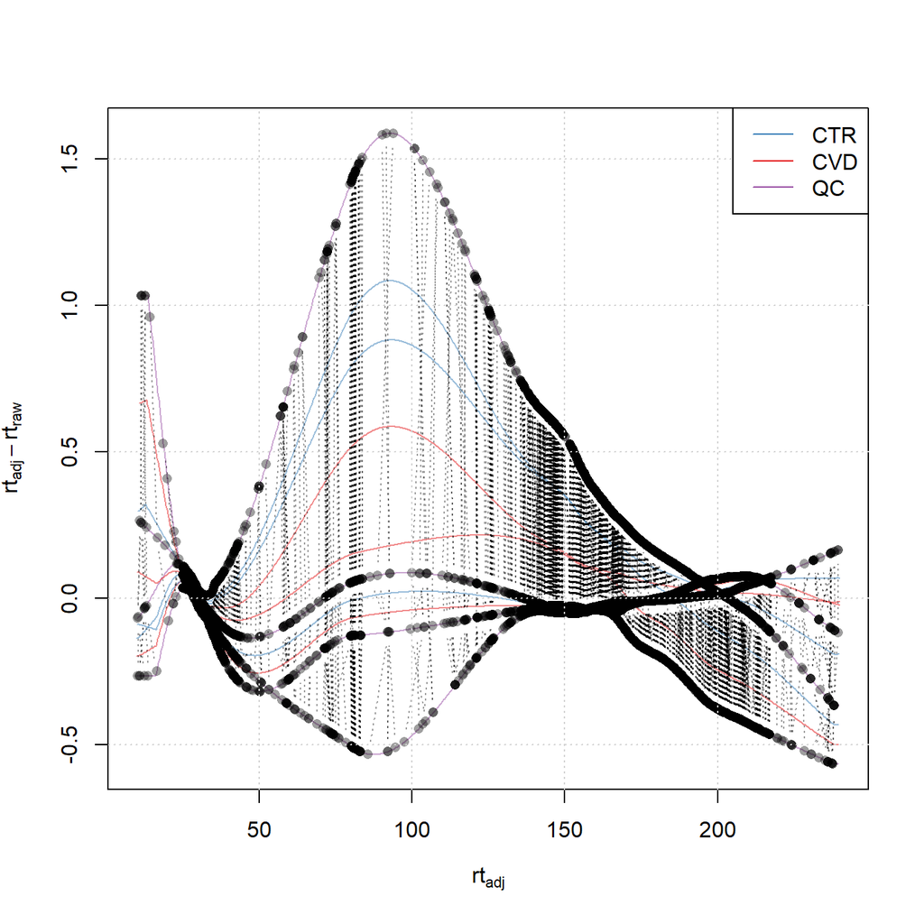

```r
#' Define parameters of choice
param <- PeakGroupsParam(minFraction = 0.9, extraPeaks = 50, span = 0.3,
                       subsetAdjust = "average",
                       subset = which(sampleData(data)$phenotype == "QC"))

#' Input in the function
data <- adjustRtime(data, param = param)

#' See result
plotAdjustedRtime(data, col = paste0(col_phenotype[bpc$phenotype], 80))
grid()
legend("topright", col = col_phenotype,
       legend = names(col_phenotype), lty = 1)
```

We can also compare before and after alignment, to access data before the process, the function `dropAdjustedRtime()` can be used:

```r
#' get  data before alignment
data_raw <- dropAdjustedRtime(data)
```

We can use this to compare the BPC before and after alignment

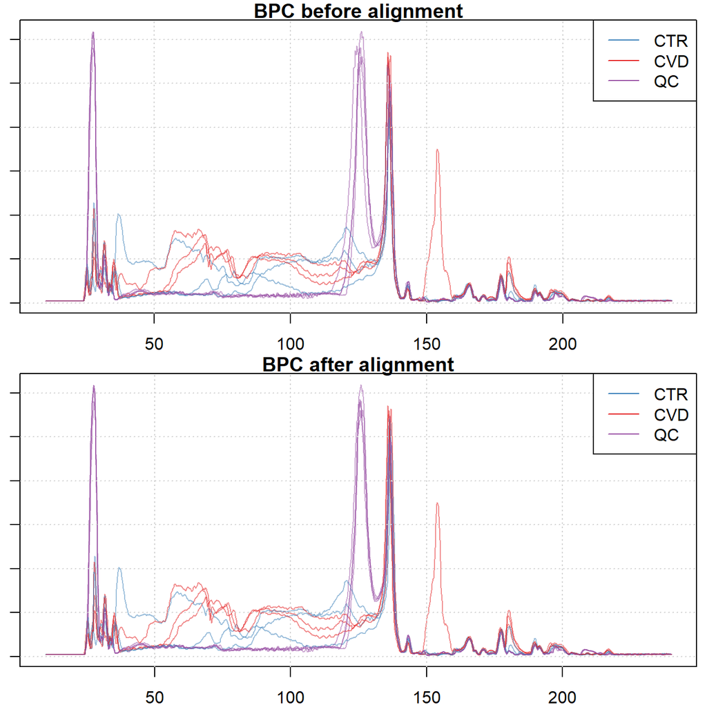

- use subset alignment.

Can also observe it in our ions of interest:

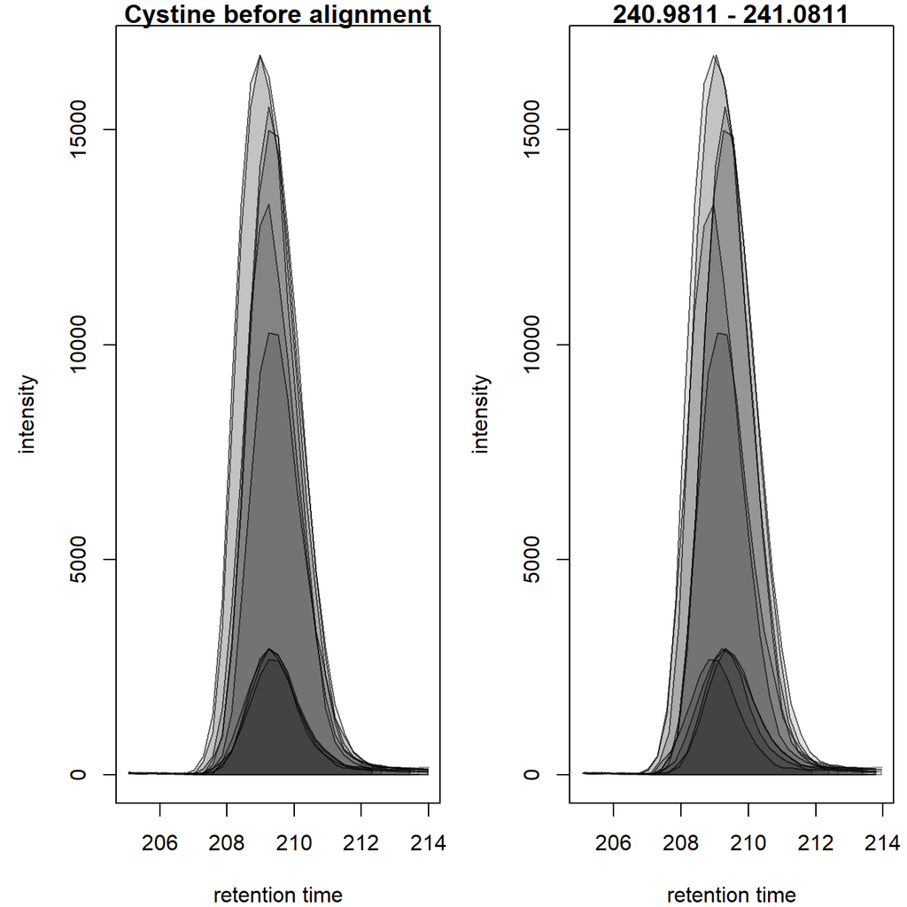

Little difference

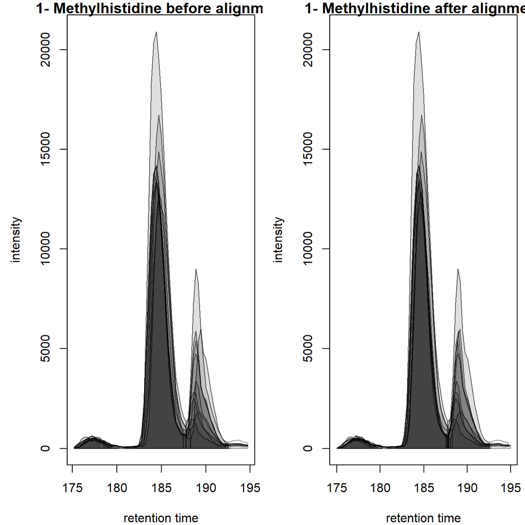

Our test ions did not display any significant differences between the raw and adjusted data.

Use another ion as example…

## Correspondence

- use *bad* settings (check maybe xcmsTutorials for examples)

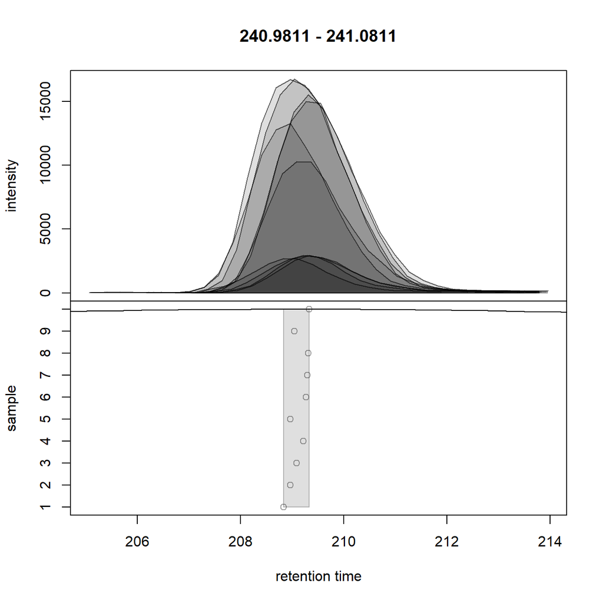

```r
#' Default parameter for the grouping and apply them to the test ions BPC
param <- PeakDensityParam(sampleGroups = sampleData(data)$phenotype, bw = 30)

plotChromPeakDensity(eic_cystine, param = param)
```

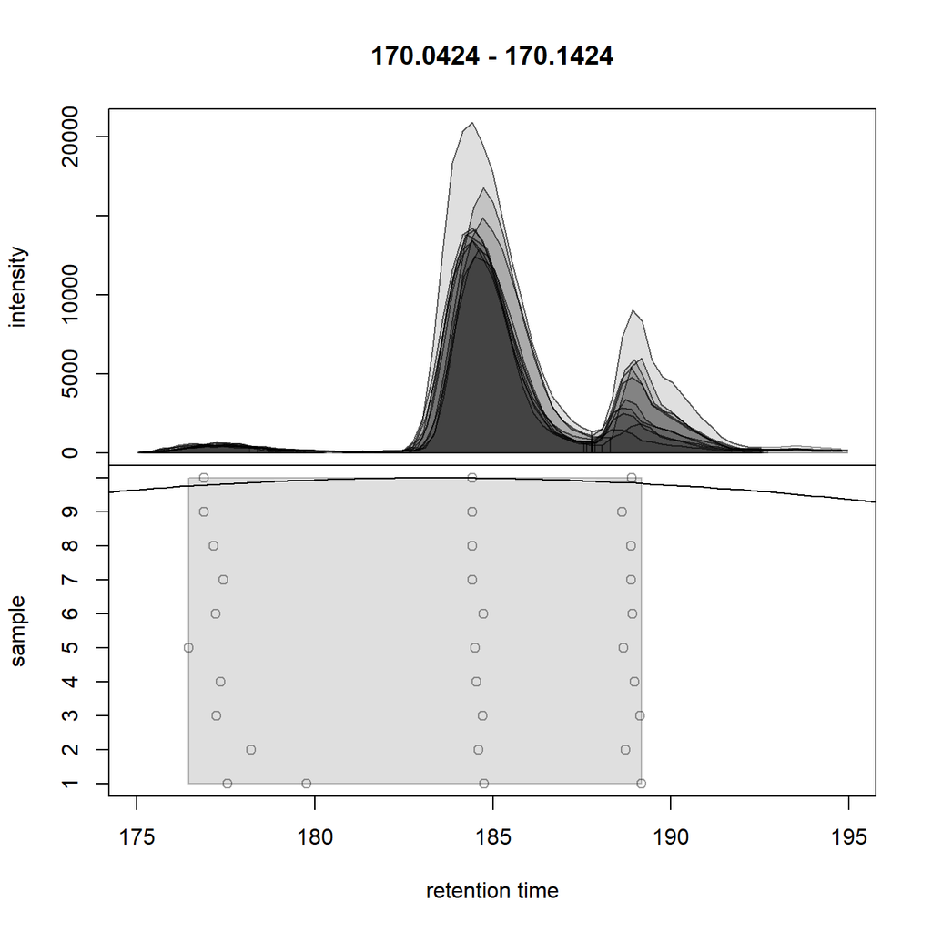

```r
plotChromPeakDensity(eic_Met, param = param)
```

- Good settings

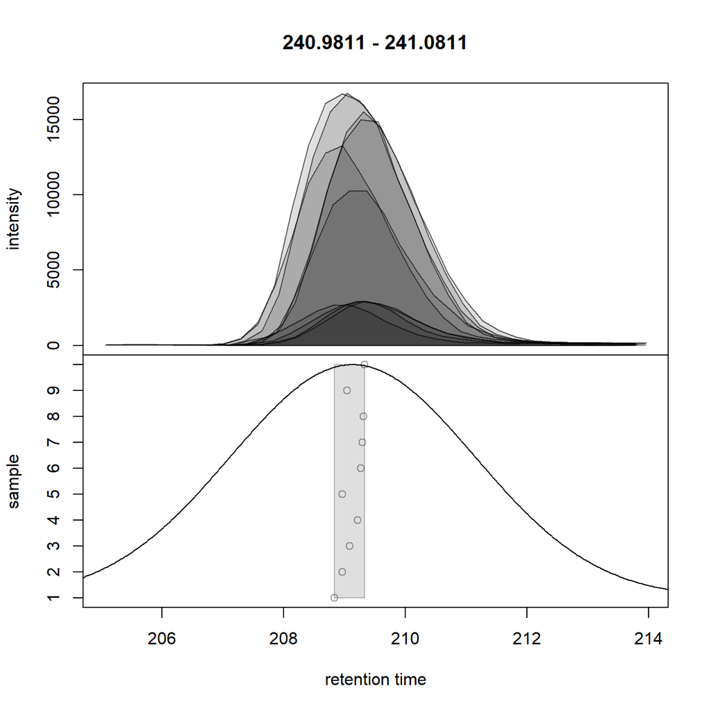

```r
#'Updating parameters
param <- PeakDensityParam(sampleGroups = sampleData(data)$phenotype,
                        minFraction = 1/3, binSize = 0.015, bw = 2)

plotChromPeakDensity(eic_cystine, param = param)
```

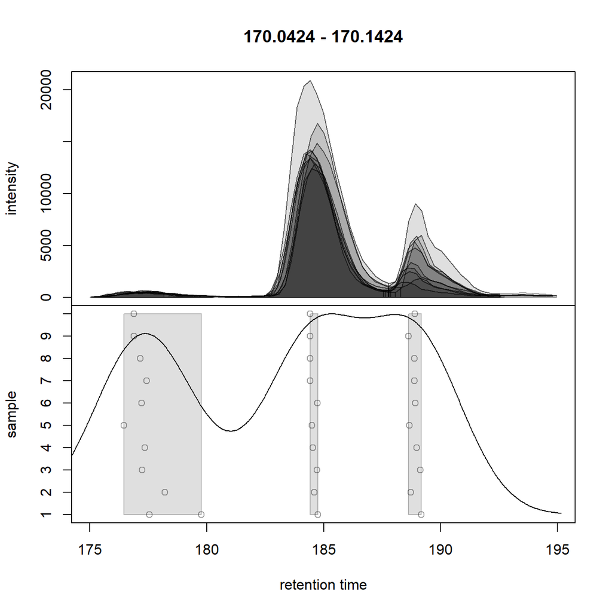

```r
plotChromPeakDensity(eic_Met, param = param)
```

Now…

```r
#' Now apply to whole data
data <- groupChromPeaks(data, param = param)
```

Test by checking an area with ions that are isomers: 1-Methylhistidine and 3-Methylhistidine

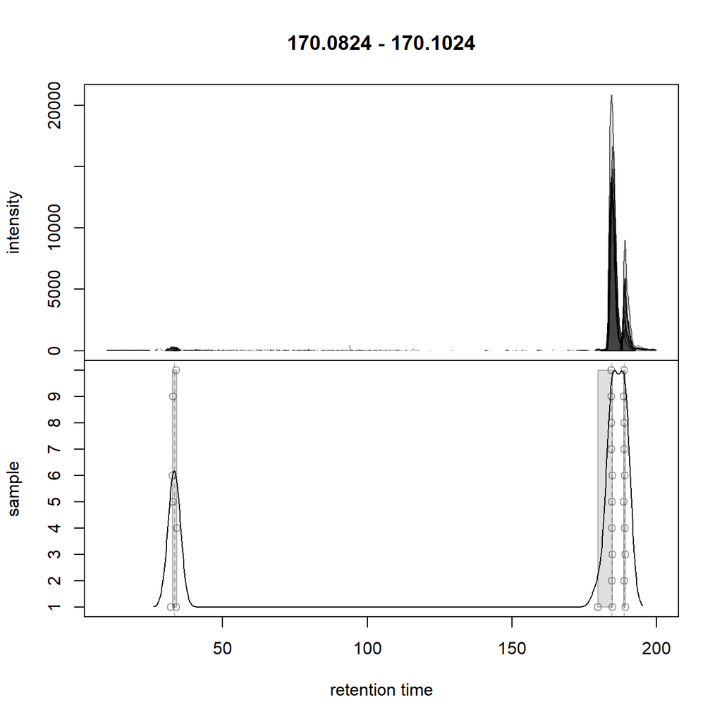

```r
#' Extract chromatogram with signal for isomers 1-Methylhistidine and
#' 3-Methylhistidine
chr_test <- chromatogram(data, mz = Met_mz + c(-0.01, 0.01),
                         rt = c(0, 200),aggregationFun = "max")
plotChromPeakDensity(chr_test, simulate = FALSE)
```

Looks good

resulting object:

```r
#' Definition of the features
featureDefinitions(data) |>
  head()
```

```
##            mzmed    mzmin    mzmax    rtmed    rtmin    rtmax npeaks CTR CVD QC
## FT00001 50.98978 50.98919 50.99038 203.7274 203.1161 204.3711      9   2   3  4
## FT00002 51.05902 51.05878 51.05941 191.1636 190.8639 191.6260     10   3   3  4
## FT00003 51.98654 51.98601 51.98699 203.1327 202.6270 203.8167      9   2   3  4
## FT00004 53.02036 53.02009 53.02043 203.2319 202.5613 204.0939     10   3   3  4
## FT00005 53.01578 53.01559 53.01596 227.1058 225.8595 228.3521      2   0   1  0
## FT00006 53.01574 53.01574 53.01574 233.3378 233.3378 233.3378      1   0   1  0
##              peakidx ms_level
## FT00001 8353, 18....        1
## FT00002 7923, 17....        1
## FT00003 8379, 18....        1
## FT00004 8636, 18....        1
## FT00005 18680, 18811        1
## FT00006        18812        1
```

```r
featureValues(data, method = "sum") |>
  head()
```

```
##         20180622_QC4_POS.mzML 20180622_ARVD 15_POS.mzML 20180622_CTR21_POS.mzML
## FT00001              421.6162                  689.2422                447.4221
## FT00002              766.8946                  875.9192                409.9167
## FT00003              470.9062                  653.6164                536.1014
## FT00004            17289.7276                23907.5783              18565.4535
## FT00005                    NA                 1367.1917                      NA
## FT00006                    NA                  823.3329                      NA
##         20180622_QC7_POS.mzML 20180622_CTR25_POS.mzML 20180622_ARVD 8_POS.mzML
## FT00001              481.7436                      NA                 635.2732
## FT00002              746.8879                795.7672                 819.0375
## FT00003              509.8901                      NA                 634.9370
## FT00004            18022.8657              23097.6208               22873.1061
## FT00005                    NA                      NA                       NA
## FT00006                    NA                      NA                       NA
##         20180622_QC8_POS.mzML 20180622_CTR22_POS.mzML 20180622_ARVD 5_POS.mzML
## FT00001              439.6086                570.5849                 579.9360
## FT00002              700.9716               1054.0207                 534.4577
## FT00003              483.4569                628.7389                 597.1793
## FT00004            17154.4801              23055.4759               22557.9577
## FT00005                    NA                      NA                       NA
## FT00006                    NA                      NA                       NA
##         20180622_QC9_POS.mzML
## FT00001              437.0340
## FT00002              711.0361
## FT00003              467.5585
## FT00004            16904.4920
## FT00005                    NA
## FT00006                    NA
```

F00005 and F00006 contain missing values in some samples

## Gap filling

Process to try to rescue some (pre-)selected peaks that are only detected in a subset of samples.

```
##         20180622_QC4_POS.mzML 20180622_ARVD 15_POS.mzML 20180622_CTR21_POS.mzML
## FT00001                 FALSE                     FALSE                   FALSE
## FT00002                 FALSE                     FALSE                   FALSE
## FT00003                 FALSE                     FALSE                   FALSE
## FT00004                 FALSE                     FALSE                   FALSE
## FT00005                  TRUE                     FALSE                    TRUE
## FT00006                  TRUE                     FALSE                    TRUE
##         20180622_QC7_POS.mzML 20180622_CTR25_POS.mzML 20180622_ARVD 8_POS.mzML
## FT00001                 FALSE                    TRUE                    FALSE
## FT00002                 FALSE                   FALSE                    FALSE
## FT00003                 FALSE                    TRUE                    FALSE
## FT00004                 FALSE                   FALSE                    FALSE
## FT00005                  TRUE                    TRUE                     TRUE
## FT00006                  TRUE                    TRUE                     TRUE
##         20180622_QC8_POS.mzML 20180622_CTR22_POS.mzML 20180622_ARVD 5_POS.mzML
## FT00001                 FALSE                   FALSE                    FALSE
## FT00002                 FALSE                   FALSE                    FALSE
## FT00003                 FALSE                   FALSE                    FALSE
## FT00004                 FALSE                   FALSE                    FALSE
## FT00005                  TRUE                    TRUE                     TRUE
## FT00006                  TRUE                    TRUE                     TRUE
##         20180622_QC9_POS.mzML
## FT00001                 FALSE
## FT00002                 FALSE
## FT00003                 FALSE
## FT00004                 FALSE
## FT00005                  TRUE
## FT00006                  TRUE
```

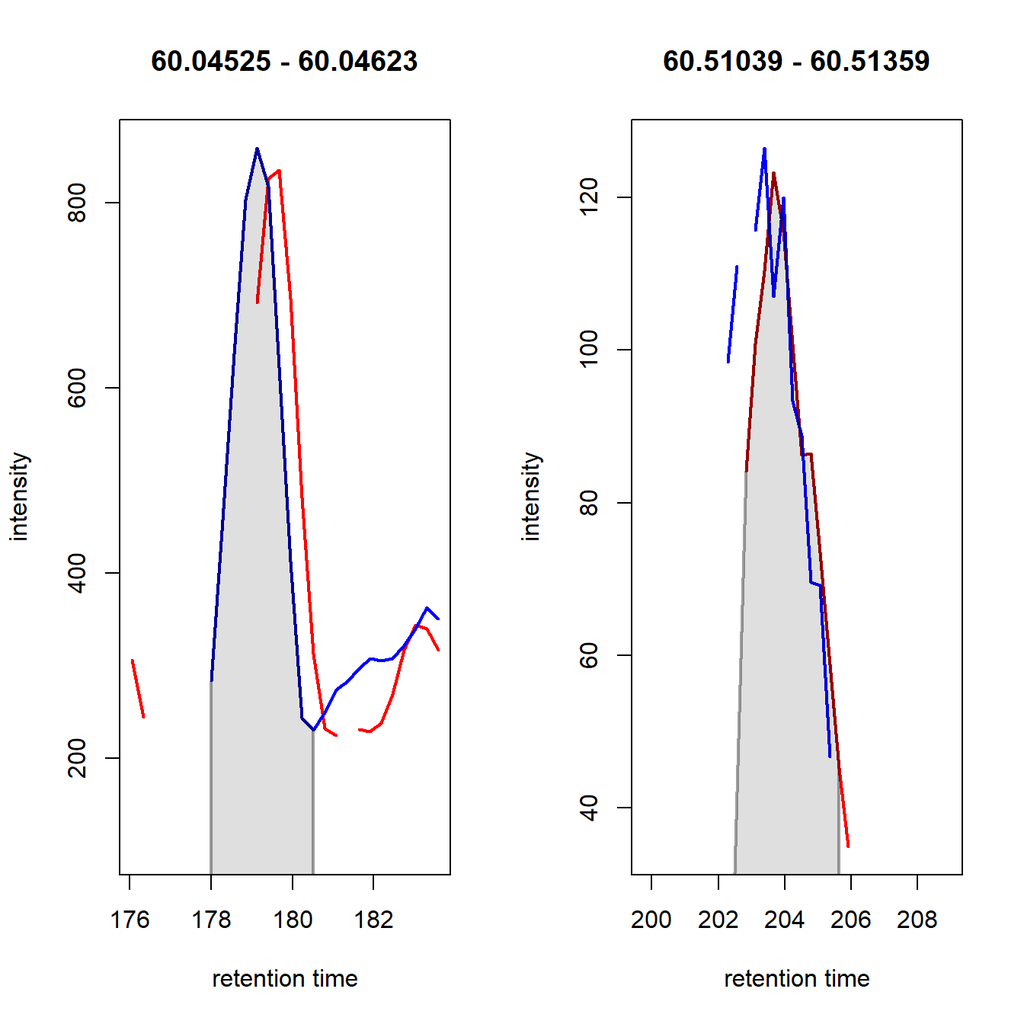

```r
#' Number of missing values
sum(is.na(featureValues(data)))
```

```
## [1] 102348
```

We can see quite a large amount of NA values in our data set.

```r
data <- fillChromPeaks(data, param = ChromPeakAreaParam(), chunkSize = 5)

#' How many missing values after
sum(is.na(featureValues(data)))
```

```
## [1] 19126
```

Show the rescued peaks:

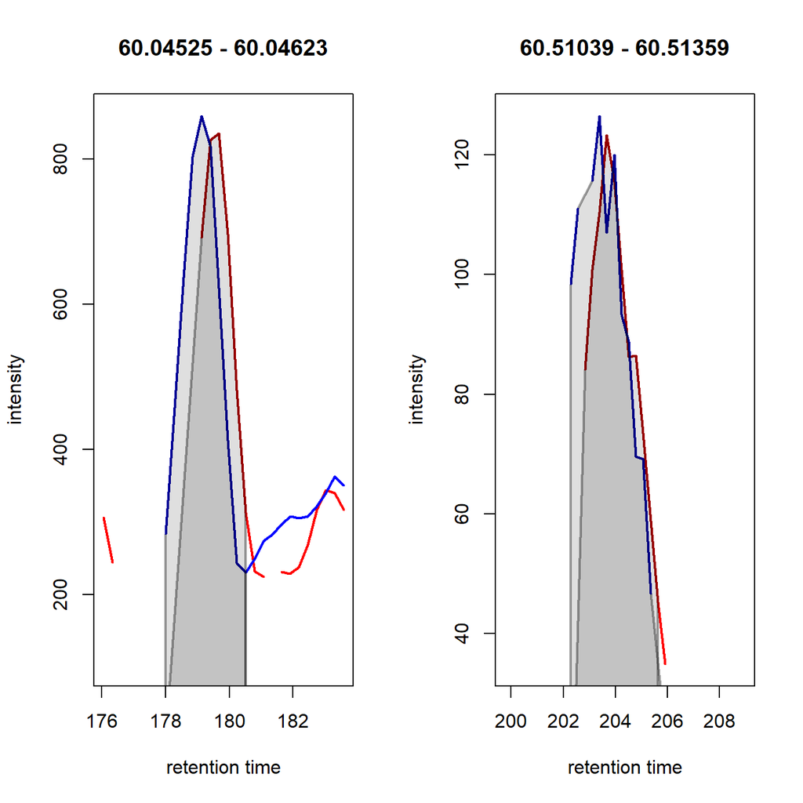

ANother way to confirm gap-filling rescued signals. use QC sample signals as basis

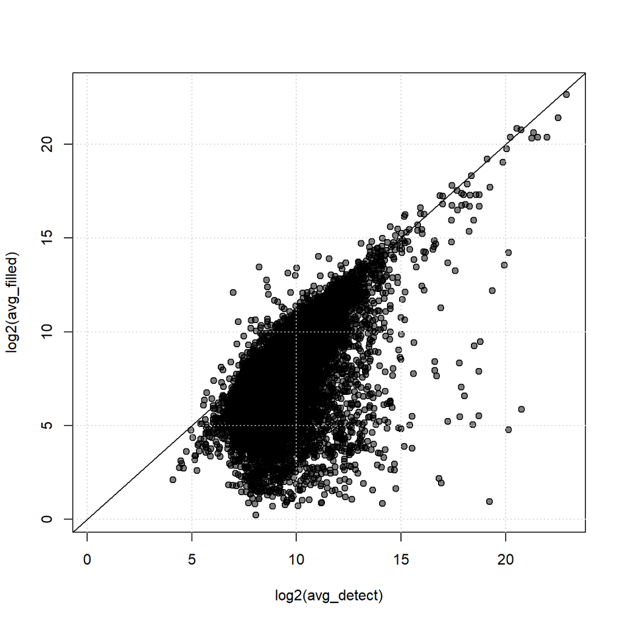

```r
#' Get only detected signal
vals_detect <- featureValues(data, filled = FALSE)

#' Get detected and filled-in signal
vals_filled <- featureValues(data)

#' Replace detected signal with NA
vals_filled[!is.na(vals_detect)] <- NA

#' Identify features with at least one filled peak
has_filled <- is.na(rowSums(vals_detect))

#' Calculate row averages
avg_detect <- rowMeans(vals_detect, na.rm = TRUE)
avg_filled <- rowMeans(vals_filled, na.rm = TRUE)

#' Restrict to features with at least one filled peak
avg_detect <- avg_detect[has_filled]
avg_filled <- avg_filled[has_filled]

#' plot the values against each other (in log2 scale)
plot(log2(avg_detect), log2(avg_filled),
     xlim = range(log2(c(avg_detect, avg_filled)), na.rm = TRUE),
     ylim = range(log2(c(avg_detect, avg_filled)), na.rm = TRUE),
     pch = 21, bg = "#00000080")
grid()
abline(0, 1)
```

Then calculate statistics on these values. below we fit a linear regression line to the data and summarize its results

```r
#' fit a linear regression line to the data
l <- lm(log2(avg_filled) ~ log2(avg_detect))
summary(l)
```

```
##
## Call:
## lm(formula = log2(avg_filled) ~ log2(avg_detect))
##
## Residuals:
##      Min       1Q   Median       3Q      Max
## -14.6648  -0.6862   0.3034   1.1152   6.7210
##
## Coefficients:
##                  Estimate Std. Error t value Pr(>|t|)
## (Intercept)      0.110003   0.079485   1.384    0.166
## log2(avg_detect) 0.806552   0.008545  94.389   <2e-16 ***
## ---
## Signif. codes:  0 '***' 0.001 '**' 0.01 '*' 0.05 '.' 0.1 ' ' 1
##
## Residual standard error: 1.724 on 15647 degrees of freedom
##   (379 observations deleted due to missingness)
## Multiple R-squared:  0.3628, Adjusted R-squared:  0.3628
## F-statistic:  8909 on 1 and 15647 DF,  p-value: < 2.2e-16
```

## Pre-processing result

The final reuslts of these steps are stored within the `XcmsExperiement` object. This includes the identified chromatographic peaks, the alignment results as well as the correspondence results. In addition, to guarantee reproducibility, this result object keeps track of all performed processing steps and contains also the individual parameter objects used in the various preprocessing steps. These can be extracted with the `processHistory` function:

```r
#' Process history
processHistory(data)
```

```
## [[1]]
## Object of class "XProcessHistory"
##  type: Peak detection
##  date: Wed Oct  4 11:15:59 2023
##  info:
##  fileIndex: 1,2,3,4,5,6,7,8,9,10
##  Parameter class: CentWaveParam
##  MS level(s) 1
##
## [[2]]
## Object of class "XProcessHistory"
##  type: Peak refinement
##  date: Wed Oct  4 11:17:55 2023
##  info:
##  fileIndex: 1,2,3,4,5,6,7,8,9,10
##  Parameter class: MergeNeighboringPeaksParam
##  MS level(s) 1
##
## [[3]]
## Object of class "XProcessHistory"
##  type: Peak grouping
##  date: Wed Oct  4 11:18:50 2023
##  info:
##  fileIndex: 1,2,3,4,5,6,7,8,9,10
##  Parameter class: PeakDensityParam
##  MS level(s) 1
##
## [[4]]
## Object of class "XProcessHistory"
##  type: Retention time correction
##  date: Wed Oct  4 11:19:02 2023
##  info:
##  fileIndex: 1,2,3,4,5,6,7,8,9,10
##  Parameter class: PeakGroupsParam
##  MS level(s) 1
##
## [[5]]
## Object of class "XProcessHistory"
##  type: Peak grouping
##  date: Wed Oct  4 11:21:25 2023
##  info:
##  fileIndex: 1,2,3,4,5,6,7,8,9,10
##  Parameter class: PeakDensityParam
##  MS level(s) 1
##
## [[6]]
## Object of class "XProcessHistory"
##  type: Missing peak filling
##  date: Wed Oct  4 11:24:12 2023
##  info:
##  fileIndex: 1,2,3,4,5,6,7,8,9,10
##  Parameter class: ChromPeakAreaParam
##  MS level(s) 1
```

These pre-processing steps results in the two-dimensional matrix with abundances of the so-called LC-MS features in all samples. At this stage the features are only characterized by their m/z and retention time.

extract results of pre-processing:

```r
#' Extract results as a SummarizedExperiment
library(SummarizedExperiment)

res <- quantify(data, method = "sum")
res
```

```
## class: SummarizedExperiment
## dim: 19043 10
## metadata(6): '' '' ... '' ''
## assays(1): raw
## rownames(19043): FT00001 FT00002 ... FT19042 FT19043
## rowData names(11): mzmed mzmin ... QC ms_level
## colnames(10): 20180622_QC4_POS.mzML 20180622_ARVD 15_POS.mzML ...
##   20180622_ARVD 5_POS.mzML 20180622_QC9_POS.mzML
## colData names(5): mzML_file injection_index phenotype sample_name
##   spectraOrigin
```

```r
#' Subset to the first 15 features
res[1:15, ]
```

```
## class: SummarizedExperiment
## dim: 15 10
## metadata(6): '' '' ... '' ''
## assays(1): raw
## rownames(15): FT00001 FT00002 ... FT00014 FT00015
## rowData names(11): mzmed mzmin ... QC ms_level
## colnames(10): 20180622_QC4_POS.mzML 20180622_ARVD 15_POS.mzML ...
##   20180622_ARVD 5_POS.mzML 20180622_QC9_POS.mzML
## colData names(5): mzML_file injection_index phenotype sample_name
##   spectraOrigin
```

Te features values are stored as an *assay* wihtin the obejct adn can be accessed using the `assay()` function:

```r
#' Get feature values
assay(res) |> head()
```

```
##         20180622_QC4_POS.mzML 20180622_ARVD 15_POS.mzML 20180622_CTR21_POS.mzML
## FT00001              421.6162                  689.2422                447.4221
## FT00002              766.8946                  875.9192                409.9167
## FT00003              470.9062                  653.6164                536.1014
## FT00004            17289.7276                23907.5783              18565.4535
## FT00005              562.4805                 1367.1917                783.8502
## FT00006              384.7731                  823.3329                712.7406
##         20180622_QC7_POS.mzML 20180622_CTR25_POS.mzML 20180622_ARVD 8_POS.mzML
## FT00001              481.7436                298.3515                 635.2732
## FT00002              746.8879                795.7672                 819.0375
## FT00003              509.8901                586.8679                 634.9370
## FT00004            18022.8657              23097.6208               22873.1061
## FT00005              860.2094                731.0905                 858.7232
## FT00006              619.6189                764.6011                 664.1724
##         20180622_QC8_POS.mzML 20180622_CTR22_POS.mzML 20180622_ARVD 5_POS.mzML
## FT00001              439.6086                570.5849                 579.9360
## FT00002              700.9716               1054.0207                 534.4577
## FT00003              483.4569                628.7389                 597.1793
## FT00004            17154.4801              23055.4759               22557.9577
## FT00005              688.9753                592.0278                 723.9089
## FT00006              640.6365                689.1108                 769.5412
##         20180622_QC9_POS.mzML
## FT00001              437.0340
## FT00002              711.0361
## FT00003              467.5585
## FT00004            16904.4920
## FT00005              768.1187
## FT00006              729.4229
```

# Data normalization

After preprocessing, the data could be normalized or scaled to remove any technical variances from the data. While a simple e.g. median scaling could be done with a few lines of R code also more advanced (but not always needed) normalization algorithms are available in e.g. Bioconductor’s preprocessCore package.

- between sample normalization
- maybe skip signal drift normalization
- Evaluation on IS.

# Identification of interesting features

- Pre-filtering.
- Differential abundance.

Task: sensitivity analysis: with/without normalization. with/without pre-filtering.

# Annotation

- Different levels of annotation.
- Just m/z (mass).
- m/z and retention time.
- MS/MS spectra + public repository.
- MS/MS spectra + retention time.